# Artigo: A melhora da depressão reduz a interferência da dor crônica na vida diária

Author

Prof. Tatiane Moraes - Institute of Social Medicine/UERJ

## 1 Introdução

Este documento consolida a formatação e revisão do banco de dados de pacientes da Clínica da Dor do Hospital Universitário Pedro Ernesto - HUPE da UERJ. Este banco de dados é composto por pacientes que finalizaram o Programa de Autogerenciamento da Dor Crônica (PADC) promovido por equipe multidisciplar da Clínica da Dor.

O banco e as análises aqui apresentadas têm como objetivo identificar o papel da melhora da depressão na melhora da intensidade e da interferencia da dor e integram a dissertação de mestrado e artigo liderado por Paula Assunção.

## 2 Consolidação do Banco de Dados

### 2.1 Descrição das variáveis

As variáveis que compoem o banco e que são de interesse deste projeto são:

1. **Variáveis Resposta**

**Melhora da intensidade da dor:**

Estimada a partir dos resultados do Inventário Breve de Dor (BPI), considerando a diferenca entre o score obtido no momento basal e na reavaliação, após o PADC, onde a redução de dois pontos ou mais indica melhora na intensidade da dor, ou seja:

**Melhora da interferência da dor:**

Estimada a partir dos resultados do Inventário Breve de Dor (BPI), considerando a diferenca entre o score obtido no momento basal e na reavaliação, após o PADC, onde a redução de dois pontos ou mais indica melhora na interferência da dor, ou seja:

**Melhora da depressão:**

Estimada através da diferença entre o score obtido no momento basal e no momento de reavaliação. Foram considerados deprimidos os pacientes cujo score era igual ou superior a 11. Assim, foram identificados e categorizados os seguintes grupos:

Grupo 1 - Pacientes sem depressão no momento basal e na reavaliação

Grupo 2 - Pacientes com depressão no momento basal que apresentaram remissão na reavaliação

Grupo 3 - Pacientes com depressão persistente (com depressão no momento basal que não melhoraram da depressão na reavaliação)

Grupo 4 - Pacientes não deprimidos no momento basal e deprimidos na realiação

3. **Variáveis de Controle:**

**Faixa etária**: 18 a 39, 40 a 59 e maiores de 60 anos

**Sexo**: Masculino e feminino

**Raça**: Branco, Não brando (negro, indígena, amarelo e pardo) e não informado

**Escolaridade**: <9 anos: não estudou e ensino fundamental incompleto; 9-12 anos: fundamento completo e ensino médio incompleto e completo; > 12 anos: ensino superior incompleto e completo.

**IMC**: normal: ≥ 17 a < 25 kg/m²; sobrepeso: ≥ 25 a < 30 kg/m²; e obesidade ≥ 30 kg/m²

**Uso de antidepressivos**: Sim e Nao

### 2.2 Organização do Banco

Baixar banco de pacientes que finalizaram o PADC, selecionar aqueles que finalizaram de modo presencial e manter somentes as variaveis de intesse no banco: melhora intensidade, melhora interferência, melhora depressão, imc e imc cetgorico, idade e idade categorico, sexo e uso de antidepressivos. Ao final, avaliar missing de cada variável e criar nova variavel IMC_cat, mantendo missing quando necessário. Tambem categorizar variaveis de escolaridade e raça

```r
banco_dor_presencial <- read.csv("UerjDataCleanv8.csv", sep = ";", dec = ",", header = TRUE)
head(banco_dor_presencial)

library(dplyr)
banco_dor_presencial <- banco_dor_presencial %>%
  filter(MODALIDADE_ONLINE == 0)

summary(banco_dor_presencial)
colnames(banco_dor_presencial)

banco_dor_presencial <- banco_dor_presencial %>%
  select("codigo", "MODALIDADE_ONLINE", "Sexo", "Raça",
  "Escolaridade", "EscolariedadeNumerica",
  "score_HADS_depressao", "score_HADS_ansiedade",
  "Intensidadedador_B", "Interferenciadador_B",
  "Peso", "Altura", "IMC", "Antidepressivos",
  "score_Ansiedade_reavaliacao", "score_depressao_reavaliacao",
  "Melhora_Intensidade", "melhora_interferencia",
  "IMC_cat", "IDADE_cat")

summary(banco_dor_presencial)
head(banco_dor_presencial)

banco_dor_presencial <- banco_dor_presencial %>%
  mutate(sexo_cat = ifelse(Sexo == "F", 1, 0))
str(banco_dor_presencial)

#Avaliaçao de missing
colSums(is.na(banco_dor_presencial))
banco_dor_presencial <- banco_dor_presencial %>%
  select(-IMC_cat)
#refazendo variável imc_cat
banco_dor_presencial <- banco_dor_presencial %>%
  mutate(imc_cat = case_when(
    is.na(IMC) ~NA_real_,
    IMC >= 17 & IMC < 25 ~1,
    IMC >= 25 & IMC < 30 ~2,
    IMC >= 30 ~3,
    TRUE ~NA_real_
  ))

#Organizar variaveis de raça e escolaridade
table(banco_dor_presencial$Raça)

library(stringr)

banco_dor_presencial <- banco_dor_presencial %>%
  mutate(
    raca_padronizada = Raça %>%
      str_trim() %>%                # remove espaços
      str_squish() %>%              # remove espaços duplicados
      str_to_lower(),               # minúsculo

    raca_cat = case_when(
      str_detect(raca_padronizada, "^branco$") ~ 1,

      str_detect(raca_padronizada, "amarelo|indigena|indígena|negro|pardo") ~ 2,

      str_detect(raca_padronizada, "não informado|nao informado") ~ 3,

      TRUE ~ NA_real_
    )
  )

banco_dor_presencial$raca_cat <- factor(
  banco_dor_presencial$raca_cat,
  levels = c(1, 2, 3),
  labels = c("Branco", "Não branco", "Não informado")
)
table(banco_dor_presencial$raca_cat)

table(banco_dor_presencial$Escolaridade)

banco_dor_presencial <- banco_dor_presencial %>%
  mutate(
    esc_pad = Escolaridade %>%
      str_trim() %>%
      str_to_lower(),

    escol_cat = case_when(

      # < 9 anos
      str_detect(esc_pad, "nunca estudou|fundamental incompleto") ~ 1,

      # 9–12 anos
      str_detect(esc_pad, "fundamental completo|médio|medio") ~ 2,

      # > 12 anos
      str_detect(esc_pad, "superior") ~ 3,

      # não informado
      str_detect(esc_pad, "não informado|nao informado") ~ NA_real_,

      TRUE ~ NA_real_
    )
  )

banco_dor_presencial$escol_cat <- factor(
  banco_dor_presencial$escol_cat,
  levels = c(1, 2, 3),
  labels = c("< 9 anos", "9–12 anos", "> 12 anos")
)

table (banco_dor_presencial$escol_cat)
```

**Variável Melhora da Depreessão**

Estimar melhora da depressão, criando variável categorica dos grupos, onde:

Grupo 1 (referencia) - Se score_HADS_depressao e score_depressao_reavaliação < 11 (sem depressão antes e depois)

Grupo 2 (melhorados) - Se score_HADS_depressao > 11 e e score_depressao_reavaliação <11 (com depressão antes e sem depressao depois)

Grupo 3 (deprimidos não melhorados) - Se score_HADS_depressao e score_depressao_reavaliação > 11 (com depressão antes e depois)

Grupo 4 (piorados) - Se score_HADS_depressao < 11 e e score_depressao_reavaliação > 11 (sem depressão antes e com depressao depois)

```r
summary(banco_dor_presencial)

banco_dor_presencial <- banco_dor_presencial %>%
  mutate(melhora_depressao = case_when(
    score_HADS_depressao < 11 & score_depressao_reavaliacao < 11 ~ 0,  # Não deprimidos
    score_HADS_depressao >= 11 & score_depressao_reavaliacao < 11 ~ 1,  # Melhorados
    score_HADS_depressao >= 11 & score_depressao_reavaliacao >= 11 ~ 2,  # Não melhorados
    score_HADS_depressao < 11 & score_depressao_reavaliacao >= 11 ~ 3,  # Deprimidos após
    TRUE ~ NA_real_
  ))
table(banco_dor_presencial$melhora_depressao)
```

### 2.3 Tabela Descritiva Sumário

Organizacao do banco e visualização dos dados para composição das informações descritivas da Tabela 1 do artigo.

```r
#tabela descritiva:
variaveis <- c("IDADE_cat", "imc_cat", "sexo_cat",
               "Antidepressivos", "melhora_depressao","escol_cat", "raca_cat")

tabela_descritiva <- lapply(variaveis, function(var) {

  tab <- table(banco_dor_presencial[[var]], useNA = "ifany")
  prop <- prop.table(tab) * 100

  data.frame(
    Variavel = var,
    Categoria = names(tab),
    Frequencia = as.vector(tab),
    Percentual = round(as.vector(prop), 2)
  )
})

tabela_descritiva <- do.call(rbind, tabela_descritiva)

tabela_descritiva
```

```
            Variavel     Categoria Frequencia Percentual
1          IDADE_cat             1         26       4.56
2          IDADE_cat             2        324      56.84
3          IDADE_cat             3        220      38.60
4            imc_cat             1        107      18.77
5            imc_cat             2        165      28.95
6            imc_cat             3        228      40.00
7            imc_cat          <NA>         70      12.28
8           sexo_cat             0        127      22.28
9           sexo_cat             1        443      77.72
10   Antidepressivos             0        354      62.11
11   Antidepressivos             1        216      37.89
12 melhora_depressao             0        266      46.67
13 melhora_depressao             1        106      18.60
14 melhora_depressao             2        134      23.51
15 melhora_depressao             3         64      11.23
16         escol_cat      < 9 anos        192      33.68
17         escol_cat     9–12 anos        294      51.58
18         escol_cat     > 12 anos         81      14.21
19         escol_cat          <NA>          3       0.53
20          raca_cat        Branco        192      33.68
21          raca_cat    Não branco        345      60.53
22          raca_cat Não informado         33       5.79
```

```r
library(gtsummary)

banco_dor_presencial %>%
  select(melhora_depressao, IDADE_cat, raca_cat, escol_cat, imc_cat, sexo_cat, Antidepressivos) %>%
  tbl_summary()
```

| **Characteristic** | **N = 570**<sup>1</sup> |
| --- | --- |
| melhora_depressao |  |
| 0 | 266 (47%) |
| 1 | 106 (19%) |
| 2 | 134 (24%) |
| 3 | 64 (11%) |
| IDADE_cat |  |
| 1 | 26 (4.6%) |
| 2 | 324 (57%) |
| 3 | 220 (39%) |
| raca_cat |  |
| Branco | 192 (34%) |
| Não branco | 345 (61%) |
| Não informado | 33 (5.8%) |
| escol_cat |  |
| < 9 anos | 192 (34%) |
| 9–12 anos | 294 (52%) |
| > 12 anos | 81 (14%) |
| Unknown | 3 |
| imc_cat |  |
| 1 | 107 (21%) |
| 2 | 165 (33%) |
| 3 | 228 (46%) |
| Unknown | 70 |
| sexo_cat | 443 (78%) |
| Antidepressivos | 216 (38%) |

<sup>1</sup> n (%)

```r
#Descrição das variáveis no momento pós do grupo de pacientes com depressao (variavel deprimido pos, onde 1 = deprimido e 0 = nao deprimido)
banco_dor_presencial <- banco_dor_presencial %>%
  mutate(deprimido_pos = ifelse(score_depressao_reavaliacao >= 11, 1, 0))

banco_dor_presencial$deprimido_pos <- factor(
  banco_dor_presencial$deprimido_pos,
  levels = c(0,1),
  labels = c("Não deprimido", "Deprimido")
)

table(banco_dor_presencial$deprimido_pos)
```

```
Não deprimido     Deprimido
          372           198
```

```r
tab_sex <- table(banco_dor_presencial$deprimido_pos,
             banco_dor_presencial$sexo_cat)
tab_sex
```

```
                  0   1
  Não deprimido  89 283
  Deprimido      38 160
```

```r
tab_idade <- table(banco_dor_presencial$deprimido_pos,
                   banco_dor_presencial$IDADE_cat)
tab_idade
```

```
                  1   2   3
  Não deprimido  15 191 166
  Deprimido      11 133  54
```

```r
tab_raca <- table(banco_dor_presencial$deprimido_pos,
                  banco_dor_presencial$raca_cat,
                  useNA = "ifany")
tab_raca
```

```
                Branco Não branco Não informado
  Não deprimido    123        227            22
  Deprimido         69        118            11
```

```r
tab_escol <- table(
  banco_dor_presencial$deprimido_pos,
  banco_dor_presencial$escol_cat,
  useNA = "ifany"
                   )
tab_escol
```

```
                < 9 anos 9–12 anos > 12 anos <NA>
  Não deprimido      120       193        57    2
  Deprimido           72       101        24    1
```

```r
prop.table(tab_escol, 1)*100
```

```
                  < 9 anos  9–12 anos  > 12 anos       <NA>
  Não deprimido 32.2580645 51.8817204 15.3225806  0.5376344
  Deprimido     36.3636364 51.0101010 12.1212121  0.5050505
```

```r
tab_imc <- table (banco_dor_presencial$deprimido_pos,
                  banco_dor_presencial$imc_cat,
                  useNA = "ifany")
tab_imc
```

```
                  1   2   3 <NA>
  Não deprimido  75 113 137   47
  Deprimido      32  52  91   23
```

```r
prop.table(tab_imc, 1)*100
```

```
                       1        2        3     <NA>
  Não deprimido 20.16129 30.37634 36.82796 12.63441
  Deprimido     16.16162 26.26263 45.95960 11.61616
```

```r
tab_antidepre <- table (banco_dor_presencial$deprimido_pos,
                  banco_dor_presencial$Antidepressivos,
                  useNA = "ifany")
tab_antidepre
```

```
                  0   1
  Não deprimido 244 128
  Deprimido     110  88
```

```r
prop.table(tab_antidepre, 1)*100
```

```
                       0        1
  Não deprimido 65.59140 34.40860
  Deprimido     55.55556 44.44444
```

## 3 Análises Estatísticas

Este capítulo se refere às análises estatísticas apresentadas no artigo.

### 3.1 Comparação de médias - Qui-quadrado

Comparação das médias entre deprimidos e nao deprimido pós PACD usando Qui-quadrado (Tabela 1).

```r
#Qui-quadrado de todas variáveis
tab_sex
```

```
                  0   1
  Não deprimido  89 283
  Deprimido      38 160
```

```r
chisq.test(tab_sex)$expected
```

```
                       0        1
  Não deprimido 82.88421 289.1158
  Deprimido     44.11579 153.8842
```

```r
chisq.test(tab_sex, correct = FALSE)
```

```
    Pearson's Chi-squared test

data:  tab_sex
X-squared = 1.6715, df = 1, p-value = 0.1961
```

```r
tab_idade
```

```
                  1   2   3
  Não deprimido  15 191 166
  Deprimido      11 133  54
```

```r
chisq.test(tab_idade)$expected
```

```
                        1        2         3
  Não deprimido 16.968421 211.4526 143.57895
  Deprimido      9.031579 112.5474  76.42105
```

```r
chisq.test(tab_idade, correct = FALSE)
```

```
    Pearson's Chi-squared test

data:  tab_idade
X-squared = 16.432, df = 2, p-value = 0.0002703
```

```r
tab_raca
```

```
                Branco Não branco Não informado
  Não deprimido    123        227            22
  Deprimido         69        118            11
```

```r
chisq.test(tab_raca)$expected
```

```
                   Branco Não branco Não informado
  Não deprimido 125.30526   225.1579      21.53684
  Deprimido      66.69474   119.8421      11.46316
```

```r
chisq.test(tab_raca, correct = FALSE)
```

```
    Pearson's Chi-squared test

data:  tab_raca
X-squared = 0.19415, df = 2, p-value = 0.9075
```

```r
tab_raca
```

```
                Branco Não branco Não informado
  Não deprimido    123        227            22
  Deprimido         69        118            11
```

```r
chisq.test(tab_raca)$expected
```

```
                   Branco Não branco Não informado
  Não deprimido 125.30526   225.1579      21.53684
  Deprimido      66.69474   119.8421      11.46316
```

```r
chisq.test(tab_raca, correct = FALSE)
```

```
    Pearson's Chi-squared test

data:  tab_raca
X-squared = 0.19415, df = 2, p-value = 0.9075
```

```r
tab_escol
```

```
                < 9 anos 9–12 anos > 12 anos <NA>
  Não deprimido      120       193        57    2
  Deprimido           72       101        24    1
```

```r
chisq.test(tab_escol)$expected
```

```
                 < 9 anos 9–12 anos > 12 anos     <NA>
  Não deprimido 125.30526  191.8737  52.86316 1.957895
  Deprimido      66.69474  102.1263  28.13684 1.042105
```

```r
chisq.test(tab_escol, correct = FALSE)
```

```
    Pearson's Chi-squared test

data:  tab_escol
X-squared = 1.6002, df = 3, p-value = 0.6593
```

```r
tab_imc
```

```
                  1   2   3 <NA>
  Não deprimido  75 113 137   47
  Deprimido      32  52  91   23
```

```r
chisq.test(tab_imc)$expected
```

```
                       1         2     3     <NA>
  Não deprimido 69.83158 107.68421 148.8 45.68421
  Deprimido     37.16842  57.31579  79.2 24.31579
```

```r
chisq.test(tab_imc, correct = FALSE)
```

```
    Pearson's Chi-squared test

data:  tab_imc
X-squared = 4.6596, df = 3, p-value = 0.1985
```

```r
tab_antidepre
```

```
                  0   1
  Não deprimido 244 128
  Deprimido     110  88
```

```r
chisq.test(tab_antidepre)$expected
```

```
                       0         1
  Não deprimido 231.0316 140.96842
  Deprimido     122.9684  75.03158
```

```r
chisq.test(tab_antidepre, correct = FALSE)
```

```
    Pearson's Chi-squared test

data:  tab_antidepre
X-squared = 5.5301, df = 1, p-value = 0.01869
```

### 3.2 Modelo logístico

Modelo logístico para estimar a associação entre a melhora na dor (entre grupos pre-definidos) e a intensidade da dor e a interferencia da dor usando as seguintes variáveis de controle: sexo, idade, imc e antidepressivos.

```r
summary(banco_dor_presencial)
```

```
     codigo      MODALIDADE_ONLINE     Sexo               Raça
 Min.   :  1.0   Min.   :0         Length:570         Length:570
 1st Qu.:200.2   1st Qu.:0         Class :character   Class :character
 Median :376.5   Median :0         Mode  :character   Mode  :character
 Mean   :396.3   Mean   :0
 3rd Qu.:569.8   3rd Qu.:0
 Max.   :837.0   Max.   :0

 Escolaridade       EscolariedadeNumerica score_HADS_depressao
 Length:570         Min.   :0.000         Min.   : 0.000
 Class :character   1st Qu.:1.000         1st Qu.: 7.000
 Mode  :character   Median :2.000         Median : 9.000
                    Mean   :1.667         Mean   : 9.793
                    3rd Qu.:2.000         3rd Qu.:13.000
                    Max.   :3.000         Max.   :21.000

 score_HADS_ansiedade Intensidadedador_B Interferenciadador_B      Peso
 Min.   : 0.00        Min.   : 0.000     Min.   : 0.000       Min.   : 42.00
 1st Qu.: 8.00        1st Qu.: 5.500     1st Qu.: 5.714       1st Qu.: 65.00
 Median :12.00        Median : 6.750     Median : 7.429       Median : 76.00
 Mean   :11.84        Mean   : 6.651     Mean   : 6.901       Mean   : 77.98
 3rd Qu.:15.00        3rd Qu.: 8.000     3rd Qu.: 8.679       3rd Qu.: 88.00
 Max.   :21.00        Max.   :10.000     Max.   :10.000       Max.   :135.00
                                                              NA's   :69
     Altura           IMC        Antidepressivos  score_Ansiedade_reavaliacao
 Min.   :1.390   Min.   :17.22   Min.   :0.0000   Min.   : 0.000
 1st Qu.:1.550   1st Qu.:25.55   1st Qu.:0.0000   1st Qu.: 7.000
 Median :1.610   Median :29.02   Median :0.0000   Median :10.000
 Mean   :1.621   Mean   :29.65   Mean   :0.3789   Mean   : 9.961
 3rd Qu.:1.680   3rd Qu.:32.84   3rd Qu.:1.0000   3rd Qu.:13.000
 Max.   :1.900   Max.   :48.44   Max.   :1.0000   Max.   :21.000
 NA's   :70      NA's   :70
 score_depressao_reavaliacao Melhora_Intensidade melhora_interferencia
 Min.   : 0.000              Min.   :-7.5000     Min.   :-9.5714
 1st Qu.: 5.000              1st Qu.:-2.0000     1st Qu.:-2.4286
 Median : 9.000              Median :-0.7500     Median :-1.0000
 Mean   : 8.663              Mean   :-0.7184     Mean   :-1.0547
 3rd Qu.:12.000              3rd Qu.: 0.7500     3rd Qu.: 0.4286
 Max.   :21.000              Max.   : 7.7500     Max.   : 8.7143
                             NA's   :1           NA's   :1
   IDADE_cat       sexo_cat         imc_cat      raca_padronizada
 Min.   :1.00   Min.   :0.0000   Min.   :1.000   Length:570
 1st Qu.:2.00   1st Qu.:1.0000   1st Qu.:2.000   Class :character
 Median :2.00   Median :1.0000   Median :2.000   Mode  :character
 Mean   :2.34   Mean   :0.7772   Mean   :2.242
 3rd Qu.:3.00   3rd Qu.:1.0000   3rd Qu.:3.000
 Max.   :3.00   Max.   :1.0000   Max.   :3.000
                                 NA's   :70
          raca_cat     esc_pad              escol_cat   melhora_depressao
 Branco       :192   Length:570         < 9 anos :192   Min.   :0.000
 Não branco   :345   Class :character   9–12 anos:294   1st Qu.:0.000
 Não informado: 33   Mode  :character   > 12 anos: 81   Median :1.000
                                        NA's     :  3   Mean   :0.993
                                                        3rd Qu.:2.000
                                                        Max.   :3.000

       deprimido_pos
 Não deprimido:372
 Deprimido    :198
```

```r
head(banco_dor_presencial)
```

```
  codigo MODALIDADE_ONLINE Sexo    Raça                  Escolaridade
1     21                 0    F Amarelo       Ensino médio Incompleto
2    596                 0    F Amarelo Ensino fundamental Incompleto
3    188                 0    F Amarelo      Ensino Superior Completo
4    740                 0    F Amarelo      Ensino Superior Completo
5    544                 0    F Amarelo   Ensino Fundamental Completo
6    147                 0    F Amarelo         Ensino médio Completo
  EscolariedadeNumerica score_HADS_depressao score_HADS_ansiedade
1                     2                   16                   15
2                     1                    7                   10
3                     3                    2                    0
4                     3                   17                   18
5                     1                    9                   13
6                     2                    9                   17
  Intensidadedador_B Interferenciadador_B Peso Altura      IMC Antidepressivos
```

[output cut: 27 more lines]

```r
summary(banco_dor_presencial$Melhora_Intensidade)
```

```
   Min. 1st Qu.  Median    Mean 3rd Qu.    Max.    NA's
-7.5000 -2.0000 -0.7500 -0.7184  0.7500  7.7500       1
```

```r
#transformar todas variáveis em categóricas
banco_dor_presencial$melhora_depressao <- as.factor(banco_dor_presencial$melhora_depressao)
banco_dor_presencial$sexo_cat <- as.factor(banco_dor_presencial$sexo_cat)
banco_dor_presencial$imc_cat <- as.factor(banco_dor_presencial$imc_cat)
banco_dor_presencial$IDADE_cat <- as.factor(banco_dor_presencial$IDADE_cat)
banco_dor_presencial$Antidepressivos <- as.factor(banco_dor_presencial$Antidepressivos)

#intensidade da dor
banco_dor_presencial$melhora_intens_dummy <- ifelse(banco_dor_presencial$Melhora_Intensidade <= -2, 1, 0)
banco_dor_presencial$melhora_intens_dummy <- as.factor(banco_dor_presencial$melhora_intens_dummy)

mod_intens <- glm(melhora_intens_dummy ~ melhora_depressao + sexo_cat + IDADE_cat + imc_cat + Antidepressivos,
              data = na.omit(banco_dor_presencial),
              family = binomial)

summary(mod_intens)
```

```
Call:
glm(formula = melhora_intens_dummy ~ melhora_depressao + sexo_cat +
    IDADE_cat + imc_cat + Antidepressivos, family = binomial,
    data = na.omit(banco_dor_presencial))

Coefficients:
                   Estimate Std. Error z value Pr(>|z|)
(Intercept)         0.16096    0.52534   0.306   0.7593
melhora_depressao1  0.22971    0.27234   0.843   0.3990
melhora_depressao2 -0.50894    0.28664  -1.776   0.0758 .
melhora_depressao3 -0.48587    0.37714  -1.288   0.1976
sexo_cat1           0.19004    0.25705   0.739   0.4597
IDADE_cat2         -0.89667    0.44031  -2.036   0.0417 *
IDADE_cat3         -0.71282    0.45161  -1.578   0.1145
imc_cat2           -0.30820    0.26876  -1.147   0.2515
imc_cat3           -0.73041    0.26584  -2.748   0.0060 **
Antidepressivos1   -0.03439    0.21566  -0.159   0.8733
---
Signif. codes:  0 '***' 0.001 '**' 0.01 '*' 0.05 '.' 0.1 ' ' 1

(Dispersion parameter for binomial family taken to be 1)

    Null deviance: 580.63  on 498  degrees of freedom
Residual deviance: 558.50  on 489  degrees of freedom
AIC: 578.5

Number of Fisher Scoring iterations: 4
```

```r
exp(coef(mod_intens))
```

```
       (Intercept) melhora_depressao1 melhora_depressao2 melhora_depressao3
         1.1746342          1.2582369          0.6011305          0.6151606
         sexo_cat1         IDADE_cat2         IDADE_cat3           imc_cat2
         1.2092975          0.4079257          0.4902610          0.7347695
          imc_cat3   Antidepressivos1
         0.4817112          0.9661955
```

```r
exp(confint(mod_intens))
```

```
                       2.5 %    97.5 %
(Intercept)        0.4137297 3.2868155
melhora_depressao1 0.7332214 2.1380834
melhora_depressao2 0.3377934 1.0431122
melhora_depressao3 0.2817625 1.2507785
sexo_cat1          0.7379595 2.0276521
IDADE_cat2         0.1723973 0.9851113
IDADE_cat3         0.2024782 1.2083779
imc_cat2           0.4338212 1.2466915
imc_cat3           0.2858555 0.8122125
Antidepressivos1   0.6314228 1.4724024
```

```r
#interferência da dor
banco_dor_presencial$melhora_interf_dummy <- ifelse(banco_dor_presencial$melhora_interferencia <= -2, 1, 0)
banco_dor_presencial$melhora_interf_dummy <- as.factor(banco_dor_presencial$melhora_interf_dummy)

mod_interf <- glm(melhora_interf_dummy ~ melhora_depressao + sexo_cat + IDADE_cat + imc_cat + Antidepressivos,
              data = na.omit(banco_dor_presencial),
              family = binomial)

summary(mod_interf)
```

```
Call:
glm(formula = melhora_interf_dummy ~ melhora_depressao + sexo_cat +
    IDADE_cat + imc_cat + Antidepressivos, family = binomial,
    data = na.omit(banco_dor_presencial))

Coefficients:
                   Estimate Std. Error z value Pr(>|z|)
(Intercept)        -1.56060    0.58209  -2.681  0.00734 **
melhora_depressao1  0.48070    0.26013   1.848  0.06461 .
melhora_depressao2 -0.39226    0.26143  -1.500  0.13349
melhora_depressao3 -1.02509    0.41317  -2.481  0.01310 *
sexo_cat1           0.64809    0.26080   2.485  0.01296 *
IDADE_cat2          0.53407    0.50300   1.062  0.28835
IDADE_cat3          0.36546    0.51398   0.711  0.47706
imc_cat2           -0.08156    0.26907  -0.303  0.76180
imc_cat3           -0.27251    0.25924  -1.051  0.29316
Antidepressivos1    0.11927    0.20508   0.582  0.56084
---
Signif. codes:  0 '***' 0.001 '**' 0.01 '*' 0.05 '.' 0.1 ' ' 1

(Dispersion parameter for binomial family taken to be 1)

    Null deviance: 621.51  on 498  degrees of freedom
Residual deviance: 594.98  on 489  degrees of freedom
AIC: 614.98

Number of Fisher Scoring iterations: 4
```

```r
exp(coef(mod_interf))
```

```
       (Intercept) melhora_depressao1 melhora_depressao2 melhora_depressao3
         0.2100100          1.6172126          0.6755269          0.3587642
         sexo_cat1         IDADE_cat2         IDADE_cat3           imc_cat2
         1.9118779          1.7058570          1.4411757          0.9216790
          imc_cat3   Antidepressivos1
         0.7614632          1.1266775
```

```r
exp(confint(mod_interf))
```

```
                        2.5 %    97.5 %
(Intercept)        0.06274076 0.6287602
melhora_depressao1 0.96969976 2.6938358
melhora_depressao2 0.40122560 1.1205977
melhora_depressao3 0.14924048 0.7687148
sexo_cat1          1.16191982 3.2416828
IDADE_cat2         0.66933413 4.9623724
IDADE_cat3         0.55171637 4.2670784
imc_cat2           0.54457932 1.5667673
imc_cat3           0.45894953 1.2704770
Antidepressivos1   0.75285408 1.6836975
```

### 3.3 Modelo logístico - Sem grupo piorado

Modelo logístico para estimar a associação entre a melhora na dor (entre grupos pre-definidos) e a intensidade da dor e a interferencia da dor usando as seguintes variáveis de controle: sexo, idade, imc e antidepressivos. Sem o grupo 3 (piorados)

```r
banco_dor_presencial2 <- banco_dor_presencial %>%
  filter(melhora_depressao != 3)

table(banco_dor_presencial2$melhora_depressao)
```

```
  0   1   2   3
266 106 134   0
```

```r
#transformar todas variáveis em categóricas
banco_dor_presencial2$melhora_depressao <- as.factor(banco_dor_presencial2$melhora_depressao)
banco_dor_presencial2$sexo_cat <- as.factor(banco_dor_presencial2$sexo_cat)
banco_dor_presencial2$imc_cat <- as.factor(banco_dor_presencial2$imc_cat)
banco_dor_presencial2$IDADE_cat <- as.factor(banco_dor_presencial2$IDADE_cat)
banco_dor_presencial2$Antidepressivos <- as.factor(banco_dor_presencial2$Antidepressivos)

#intensidade da dor
banco_dor_presencial2$melhora_intens_dummy <- ifelse(banco_dor_presencial2$Melhora_Intensidade <= -2, 1, 0)
banco_dor_presencial2$melhora_intens_dummy <- as.factor(banco_dor_presencial2$melhora_intens_dummy)

mod_intens <- glm(melhora_intens_dummy ~ melhora_depressao + sexo_cat + IDADE_cat + imc_cat + Antidepressivos,
              data = na.omit(banco_dor_presencial2),
              family = binomial)

summary(mod_intens)
```

```
Call:
glm(formula = melhora_intens_dummy ~ melhora_depressao + sexo_cat +
    IDADE_cat + imc_cat + Antidepressivos, family = binomial,
    data = na.omit(banco_dor_presencial2))

Coefficients:
                   Estimate Std. Error z value Pr(>|z|)
(Intercept)         0.30820    0.56060   0.550   0.5825
melhora_depressao1  0.20184    0.27334   0.738   0.4603
melhora_depressao2 -0.54433    0.28834  -1.888   0.0591 .
sexo_cat1           0.16667    0.26942   0.619   0.5362
IDADE_cat2         -1.03388    0.48365  -2.138   0.0325 *
IDADE_cat3         -0.89753    0.49482  -1.814   0.0697 .
imc_cat2           -0.32199    0.28193  -1.142   0.2534
imc_cat3           -0.71473    0.27862  -2.565   0.0103 *
Antidepressivos1    0.04346    0.22548   0.193   0.8472
---
Signif. codes:  0 '***' 0.001 '**' 0.01 '*' 0.05 '.' 0.1 ' ' 1

(Dispersion parameter for binomial family taken to be 1)

    Null deviance: 524.68  on 444  degrees of freedom
Residual deviance: 504.78  on 436  degrees of freedom
AIC: 522.78

Number of Fisher Scoring iterations: 4
```

```r
exp(coef(mod_intens))
```

```
       (Intercept) melhora_depressao1 melhora_depressao2          sexo_cat1
         1.3609679          1.2236544          0.5802321          1.1813635
        IDADE_cat2         IDADE_cat3           imc_cat2           imc_cat3
         0.3556260          0.4075758          0.7247089          0.4893260
  Antidepressivos1
         1.0444200
```

```r
exp(confint(mod_intens))
```

```
                       2.5 %    97.5 %
(Intercept)        0.4492356 4.1179496
melhora_depressao1 0.7113339 2.0825899
melhora_depressao2 0.3248592 1.0099258
sexo_cat1          0.7040163 2.0312796
IDADE_cat2         0.1362807 0.9287959
IDADE_cat3         0.1527867 1.0866162
imc_cat2           0.4169154 1.2619613
imc_cat3           0.2831410 0.8461009
Antidepressivos1   0.6698223 1.6234906
```

```r
#interferência da dor
banco_dor_presencial2$melhora_interf_dummy <- ifelse(banco_dor_presencial2$melhora_interferencia <= -2, 1, 0)
banco_dor_presencial2$melhora_interf_dummy <- as.factor(banco_dor_presencial2$melhora_interf_dummy)

mod_interf <- glm(melhora_interf_dummy ~ melhora_depressao + sexo_cat + IDADE_cat + imc_cat + Antidepressivos,
              data = na.omit(banco_dor_presencial2),
              family = binomial)

summary(mod_interf)
```

```
Call:
glm(formula = melhora_interf_dummy ~ melhora_depressao + sexo_cat +
    IDADE_cat + imc_cat + Antidepressivos, family = binomial,
    data = na.omit(banco_dor_presencial2))

Coefficients:
                   Estimate Std. Error z value Pr(>|z|)
(Intercept)        -1.40838    0.59625  -2.362   0.0182 *
melhora_depressao1  0.47370    0.26021   1.820   0.0687 .
melhora_depressao2 -0.38920    0.26199  -1.486   0.1374
sexo_cat1           0.62141    0.26866   2.313   0.0207 *
IDADE_cat2          0.36877    0.52014   0.709   0.4783
IDADE_cat3          0.23039    0.53083   0.434   0.6643
imc_cat2           -0.05948    0.27774  -0.214   0.8304
imc_cat3           -0.27121    0.26803  -1.012   0.3116
Antidepressivos1    0.13925    0.21161   0.658   0.5105
---
Signif. codes:  0 '***' 0.001 '**' 0.01 '*' 0.05 '.' 0.1 ' ' 1

(Dispersion parameter for binomial family taken to be 1)

    Null deviance: 567.42  on 444  degrees of freedom
Residual deviance: 551.19  on 436  degrees of freedom
AIC: 569.19

Number of Fisher Scoring iterations: 4
```

```r
exp(coef(mod_interf))
```

```
       (Intercept) melhora_depressao1 melhora_depressao2          sexo_cat1
         0.2445398          1.6059325          0.6775990          1.8615600
        IDADE_cat2         IDADE_cat3           imc_cat2           imc_cat3
         1.4459545          1.2590924          0.9422575          0.7624579
  Antidepressivos1
         1.1494117
```

```r
exp(confint(mod_interf))
```

```
                        2.5 %    97.5 %
(Intercept)        0.07136363 0.7568271
melhora_depressao1 0.96268365 2.6752402
melhora_depressao2 0.40200468 1.1253044
sexo_cat1          1.11407594 3.2062086
IDADE_cat2         0.54313445 4.3153828
IDADE_cat3         0.46211133 3.8245900
imc_cat2           0.54739501 1.6295399
imc_cat3           0.45160427 1.2942175
Antidepressivos1   0.75842620 1.7402868
```

### 3.4 Modelo logístico - Somando grupo de nao deprimidos no basal

Modelo logístico para estimar a associação entre a melhora na dor (entre grupos pre-definidos) e a intensidade da dor e a interferencia da dor usando as seguintes variáveis de controle: sexo, idade, imc e antidepressivos. Neste caso, estou somando os nao deprimidos com piorados , gerando o nao deprimidos no início (grupos 0 e 3) vs melhorados vs nao melhorados. Até o momento, o melhor resultado

```r
summary(banco_dor_presencial)
```

```
     codigo      MODALIDADE_ONLINE     Sexo               Raça
 Min.   :  1.0   Min.   :0         Length:570         Length:570
 1st Qu.:200.2   1st Qu.:0         Class :character   Class :character
 Median :376.5   Median :0         Mode  :character   Mode  :character
 Mean   :396.3   Mean   :0
 3rd Qu.:569.8   3rd Qu.:0
 Max.   :837.0   Max.   :0

 Escolaridade       EscolariedadeNumerica score_HADS_depressao
 Length:570         Min.   :0.000         Min.   : 0.000
 Class :character   1st Qu.:1.000         1st Qu.: 7.000
 Mode  :character   Median :2.000         Median : 9.000
                    Mean   :1.667         Mean   : 9.793
                    3rd Qu.:2.000         3rd Qu.:13.000
                    Max.   :3.000         Max.   :21.000

 score_HADS_ansiedade Intensidadedador_B Interferenciadador_B      Peso
 Min.   : 0.00        Min.   : 0.000     Min.   : 0.000       Min.   : 42.00
 1st Qu.: 8.00        1st Qu.: 5.500     1st Qu.: 5.714       1st Qu.: 65.00
 Median :12.00        Median : 6.750     Median : 7.429       Median : 76.00
 Mean   :11.84        Mean   : 6.651     Mean   : 6.901       Mean   : 77.98
 3rd Qu.:15.00        3rd Qu.: 8.000     3rd Qu.: 8.679       3rd Qu.: 88.00
 Max.   :21.00        Max.   :10.000     Max.   :10.000       Max.   :135.00
                                                              NA's   :69
     Altura           IMC        Antidepressivos score_Ansiedade_reavaliacao
 Min.   :1.390   Min.   :17.22   0:354           Min.   : 0.000
 1st Qu.:1.550   1st Qu.:25.55   1:216           1st Qu.: 7.000
 Median :1.610   Median :29.02                   Median :10.000
 Mean   :1.621   Mean   :29.65                   Mean   : 9.961
 3rd Qu.:1.680   3rd Qu.:32.84                   3rd Qu.:13.000
 Max.   :1.900   Max.   :48.44                   Max.   :21.000
 NA's   :70      NA's   :70
 score_depressao_reavaliacao Melhora_Intensidade melhora_interferencia
 Min.   : 0.000              Min.   :-7.5000     Min.   :-9.5714
 1st Qu.: 5.000              1st Qu.:-2.0000     1st Qu.:-2.4286
 Median : 9.000              Median :-0.7500     Median :-1.0000
 Mean   : 8.663              Mean   :-0.7184     Mean   :-1.0547
 3rd Qu.:12.000              3rd Qu.: 0.7500     3rd Qu.: 0.4286
 Max.   :21.000              Max.   : 7.7500     Max.   : 8.7143
                             NA's   :1           NA's   :1
 IDADE_cat sexo_cat imc_cat    raca_padronizada            raca_cat
 1: 26     0:127    1   :107   Length:570         Branco       :192
 2:324     1:443    2   :165   Class :character   Não branco   :345
 3:220              3   :228   Mode  :character   Não informado: 33
                    NA's: 70



   esc_pad              escol_cat   melhora_depressao       deprimido_pos
 Length:570         < 9 anos :192   0:266             Não deprimido:372
 Class :character   9–12 anos:294   1:106             Deprimido    :198
 Mode  :character   > 12 anos: 81   2:134
                    NA's     :  3   3: 64



 melhora_intens_dummy melhora_interf_dummy
 0   :411             0   :380
 1   :158             1   :189
 NA's:  1             NA's:  1
```

```r
colSums(is.na(banco_dor_presencial))
```

```
                     codigo           MODALIDADE_ONLINE
                          0                           0
                       Sexo                        Raça
                          0                           0
               Escolaridade       EscolariedadeNumerica
                          0                           0
       score_HADS_depressao        score_HADS_ansiedade
                          0                           0
         Intensidadedador_B        Interferenciadador_B
                          0                           0
                       Peso                      Altura
                         69                          70
                        IMC             Antidepressivos
                         70                           0
score_Ansiedade_reavaliacao score_depressao_reavaliacao
                          0                           0
        Melhora_Intensidade       melhora_interferencia
                          1                           1
                  IDADE_cat                    sexo_cat
                          0                           0
                    imc_cat            raca_padronizada
                         70                           0
                   raca_cat                     esc_pad
                          0                           0
                  escol_cat           melhora_depressao
                          3                           0
              deprimido_pos        melhora_intens_dummy
                          0                           1
       melhora_interf_dummy
                          1
```

```r
banco_dor_presencial3 <- banco_dor_presencial %>%
  mutate(
    melhora_depressao3 = case_when(
      melhora_depressao %in% c(0, 3) ~ 0,
      melhora_depressao == 1 ~ 1,
      melhora_depressao == 2 ~ 2,
      TRUE ~ NA_real_
    ),
    melhora_depressao3 = factor(
      melhora_depressao3,
      levels = c(0, 1, 2)
    )
  )
table(banco_dor_presencial3$melhora_depressao3)
```

```
  0   1   2
330 106 134
```

```r
#transformar todas variáveis em categóricas
banco_dor_presencial3$melhora_depressao <- as.factor(banco_dor_presencial3$melhora_depressao)
banco_dor_presencial3$sexo_cat <- as.factor(banco_dor_presencial3$sexo_cat)
banco_dor_presencial3$imc_cat <- as.factor(banco_dor_presencial3$imc_cat)
banco_dor_presencial3$IDADE_cat <- as.factor(banco_dor_presencial3$IDADE_cat)
banco_dor_presencial3$Antidepressivos <- as.factor(banco_dor_presencial3$Antidepressivos)

#intensidade da dor
banco_dor_presencial3$melhora_intens_dummy <- ifelse(banco_dor_presencial3$Melhora_Intensidade <= -2, 1, 0)
banco_dor_presencial3$melhora_intens_dummy <- as.factor(banco_dor_presencial3$melhora_intens_dummy)

mod_intens <- glm(melhora_intens_dummy ~ melhora_depressao3 + sexo_cat + IDADE_cat + imc_cat + Antidepressivos,
              data = na.omit(banco_dor_presencial3),
              family = binomial)

summary(mod_intens)
```

```
Call:
glm(formula = melhora_intens_dummy ~ melhora_depressao3 + sexo_cat +
    IDADE_cat + imc_cat + Antidepressivos, family = binomial,
    data = na.omit(banco_dor_presencial3))

Coefficients:
                    Estimate Std. Error z value Pr(>|z|)
(Intercept)          0.02472    0.51454   0.048  0.96168
melhora_depressao31  0.31936    0.26448   1.208  0.22724
melhora_depressao32 -0.41682    0.27869  -1.496  0.13475
sexo_cat1            0.18716    0.25649   0.730  0.46556
IDADE_cat2          -0.84617    0.43697  -1.936  0.05281 .
IDADE_cat3          -0.63560    0.44616  -1.425  0.15427
imc_cat2            -0.30549    0.26826  -1.139  0.25478
imc_cat3            -0.73884    0.26549  -2.783  0.00539 **
Antidepressivos1    -0.04224    0.21540  -0.196  0.84453
---
Signif. codes:  0 '***' 0.001 '**' 0.01 '*' 0.05 '.' 0.1 ' ' 1

(Dispersion parameter for binomial family taken to be 1)

    Null deviance: 580.63  on 498  degrees of freedom
Residual deviance: 560.26  on 490  degrees of freedom
AIC: 578.26

Number of Fisher Scoring iterations: 4
```

```r
exp(coef(mod_intens))
```

```
        (Intercept) melhora_depressao31 melhora_depressao32           sexo_cat1
          1.0250269           1.3762505           0.6591414           1.2058254
         IDADE_cat2          IDADE_cat3            imc_cat2            imc_cat3
          0.4290555           0.5296186           0.7367597           0.4776657
   Antidepressivos1
          0.9586392
```

```r
exp(confint(mod_intens))
```

```
                        2.5 %    97.5 %
(Intercept)         0.3681714 2.8036075
melhora_depressao31 0.8139926 2.3016722
melhora_depressao32 0.3758509 1.1250908
sexo_cat1           0.7366489 2.0196227
IDADE_cat2          0.1826899 1.0303458
IDADE_cat3          0.2213396 1.2931522
imc_cat2            0.4354461 1.2488860
imc_cat3            0.2836394 0.8048224
Antidepressivos1    0.6267425 1.4600084
```

```r
#interferência da dor
banco_dor_presencial3$melhora_interf_dummy <- ifelse(banco_dor_presencial3$melhora_interferencia <= -2, 1, 0)
banco_dor_presencial3$melhora_interf_dummy <- as.factor(banco_dor_presencial3$melhora_interf_dummy)

mod_interf <- glm(melhora_interf_dummy ~ melhora_depressao3 + sexo_cat + IDADE_cat + imc_cat + Antidepressivos,
              data = na.omit(banco_dor_presencial3),
              family = binomial)

summary(mod_interf)
```

```
Call:
glm(formula = melhora_interf_dummy ~ melhora_depressao3 + sexo_cat +
    IDADE_cat + imc_cat + Antidepressivos, family = binomial,
    data = na.omit(banco_dor_presencial3))

Coefficients:
                    Estimate Std. Error z value Pr(>|z|)
(Intercept)         -1.80625    0.57250  -3.155  0.00161 **
melhora_depressao31  0.64893    0.25343   2.561  0.01045 *
melhora_depressao32 -0.21962    0.25414  -0.864  0.38749
sexo_cat1            0.64172    0.25939   2.474  0.01336 *
IDADE_cat2           0.61568    0.49694   1.239  0.21537
IDADE_cat3           0.49938    0.50636   0.986  0.32403
imc_cat2            -0.07765    0.26734  -0.290  0.77145
imc_cat3            -0.28763    0.25760  -1.117  0.26417
Antidepressivos1     0.10810    0.20385   0.530  0.59589
---
Signif. codes:  0 '***' 0.001 '**' 0.01 '*' 0.05 '.' 0.1 ' ' 1

(Dispersion parameter for binomial family taken to be 1)

    Null deviance: 621.51  on 498  degrees of freedom
Residual deviance: 602.19  on 490  degrees of freedom
AIC: 620.19

Number of Fisher Scoring iterations: 4
```

```r
exp(coef(mod_interf))
```

```
        (Intercept) melhora_depressao31 melhora_depressao32           sexo_cat1
          0.1642689           1.9134910           0.8028223           1.8997363
         IDADE_cat2          IDADE_cat3            imc_cat2            imc_cat3
          1.8509181           1.6477011           0.9252839           0.7500393
   Antidepressivos1
          1.1141627
```

```r
exp(confint(mod_interf))
```

```
                         2.5 %    97.5 %
(Intercept)         0.04986044 0.4812612
melhora_depressao31 1.16247330 3.1457592
melhora_depressao32 0.48353291 1.3125227
sexo_cat1           1.15788237 3.2126590
IDADE_cat2          0.73654710 5.3325905
IDADE_cat3          0.64204893 4.8198815
imc_cat2            0.54862833 1.5677447
imc_cat3            0.45355027 1.2474830
Antidepressivos1    0.74617023 1.6606673
```

### 3.5 Predição de probabilidade - Modelo 3 (somando não deprimidos no basal)

A partir dos modelos logisticos, estimamos a probabilidade predita das variáveis estudadas para o modelo 3, onde:

Grupo 0 (referencia): nao deprimidos no inicio e nao deprimidos ou deprimidos na reavaliação

Grupo 1: melhorados da depressao

Grupo 2: não melhorados (deprimidos antes e depois)

#### 3.5.1 Intensidade da dor

```r
summary(banco_dor_presencial)
```

```
     codigo      MODALIDADE_ONLINE     Sexo               Raça
 Min.   :  1.0   Min.   :0         Length:570         Length:570
 1st Qu.:200.2   1st Qu.:0         Class :character   Class :character
 Median :376.5   Median :0         Mode  :character   Mode  :character
 Mean   :396.3   Mean   :0
 3rd Qu.:569.8   3rd Qu.:0
 Max.   :837.0   Max.   :0

 Escolaridade       EscolariedadeNumerica score_HADS_depressao
 Length:570         Min.   :0.000         Min.   : 0.000
 Class :character   1st Qu.:1.000         1st Qu.: 7.000
 Mode  :character   Median :2.000         Median : 9.000
                    Mean   :1.667         Mean   : 9.793
                    3rd Qu.:2.000         3rd Qu.:13.000
                    Max.   :3.000         Max.   :21.000

 score_HADS_ansiedade Intensidadedador_B Interferenciadador_B      Peso
 Min.   : 0.00        Min.   : 0.000     Min.   : 0.000       Min.   : 42.00
 1st Qu.: 8.00        1st Qu.: 5.500     1st Qu.: 5.714       1st Qu.: 65.00
 Median :12.00        Median : 6.750     Median : 7.429       Median : 76.00
 Mean   :11.84        Mean   : 6.651     Mean   : 6.901       Mean   : 77.98
 3rd Qu.:15.00        3rd Qu.: 8.000     3rd Qu.: 8.679       3rd Qu.: 88.00
 Max.   :21.00        Max.   :10.000     Max.   :10.000       Max.   :135.00
                                                              NA's   :69
     Altura           IMC        Antidepressivos score_Ansiedade_reavaliacao
 Min.   :1.390   Min.   :17.22   0:354           Min.   : 0.000
 1st Qu.:1.550   1st Qu.:25.55   1:216           1st Qu.: 7.000
 Median :1.610   Median :29.02                   Median :10.000
 Mean   :1.621   Mean   :29.65                   Mean   : 9.961
 3rd Qu.:1.680   3rd Qu.:32.84                   3rd Qu.:13.000
 Max.   :1.900   Max.   :48.44                   Max.   :21.000
 NA's   :70      NA's   :70
 score_depressao_reavaliacao Melhora_Intensidade melhora_interferencia
 Min.   : 0.000              Min.   :-7.5000     Min.   :-9.5714
 1st Qu.: 5.000              1st Qu.:-2.0000     1st Qu.:-2.4286
 Median : 9.000              Median :-0.7500     Median :-1.0000
 Mean   : 8.663              Mean   :-0.7184     Mean   :-1.0547
 3rd Qu.:12.000              3rd Qu.: 0.7500     3rd Qu.: 0.4286
 Max.   :21.000              Max.   : 7.7500     Max.   : 8.7143
                             NA's   :1           NA's   :1
 IDADE_cat sexo_cat imc_cat    raca_padronizada            raca_cat
 1: 26     0:127    1   :107   Length:570         Branco       :192
 2:324     1:443    2   :165   Class :character   Não branco   :345
 3:220              3   :228   Mode  :character   Não informado: 33
                    NA's: 70



   esc_pad              escol_cat   melhora_depressao       deprimido_pos
 Length:570         < 9 anos :192   0:266             Não deprimido:372
 Class :character   9–12 anos:294   1:106             Deprimido    :198
 Mode  :character   > 12 anos: 81   2:134
                    NA's     :  3   3: 64



 melhora_intens_dummy melhora_interf_dummy
 0   :411             0   :380
 1   :158             1   :189
 NA's:  1             NA's:  1
```

```r
head(banco_dor_presencial)
```

```
  codigo MODALIDADE_ONLINE Sexo    Raça                  Escolaridade
1     21                 0    F Amarelo       Ensino médio Incompleto
2    596                 0    F Amarelo Ensino fundamental Incompleto
3    188                 0    F Amarelo      Ensino Superior Completo
4    740                 0    F Amarelo      Ensino Superior Completo
5    544                 0    F Amarelo   Ensino Fundamental Completo
6    147                 0    F Amarelo         Ensino médio Completo
  EscolariedadeNumerica score_HADS_depressao score_HADS_ansiedade
1                     2                   16                   15
2                     1                    7                   10
3                     3                    2                    0
4                     3                   17                   18
5                     1                    9                   13
6                     2                    9                   17
  Intensidadedador_B Interferenciadador_B Peso Altura      IMC Antidepressivos
```

[output cut: 34 more lines]

```r
table (banco_dor_presencial3$melhora_depressao3)
```

```
  0   1   2
330 106 134
```

```r
##Intensidade da Dor
mod_intens <- glm(melhora_intens_dummy ~ melhora_depressao3 + sexo_cat + IDADE_cat + imc_cat + Antidepressivos,
              data = na.omit(banco_dor_presencial3),
              family = binomial)

summary(mod_intens)
```

```
Call:
glm(formula = melhora_intens_dummy ~ melhora_depressao3 + sexo_cat +
    IDADE_cat + imc_cat + Antidepressivos, family = binomial,
    data = na.omit(banco_dor_presencial3))

Coefficients:
                    Estimate Std. Error z value Pr(>|z|)
(Intercept)          0.02472    0.51454   0.048  0.96168
melhora_depressao31  0.31936    0.26448   1.208  0.22724
melhora_depressao32 -0.41682    0.27869  -1.496  0.13475
sexo_cat1            0.18716    0.25649   0.730  0.46556
IDADE_cat2          -0.84617    0.43697  -1.936  0.05281 .
IDADE_cat3          -0.63560    0.44616  -1.425  0.15427
imc_cat2            -0.30549    0.26826  -1.139  0.25478
imc_cat3            -0.73884    0.26549  -2.783  0.00539 **
Antidepressivos1    -0.04224    0.21540  -0.196  0.84453
---
Signif. codes:  0 '***' 0.001 '**' 0.01 '*' 0.05 '.' 0.1 ' ' 1

(Dispersion parameter for binomial family taken to be 1)

    Null deviance: 580.63  on 498  degrees of freedom
Residual deviance: 560.26  on 490  degrees of freedom
AIC: 578.26

Number of Fisher Scoring iterations: 4
```

```r
exp(coef(mod_intens))
```

```
        (Intercept) melhora_depressao31 melhora_depressao32           sexo_cat1
          1.0250269           1.3762505           0.6591414           1.2058254
         IDADE_cat2          IDADE_cat3            imc_cat2            imc_cat3
          0.4290555           0.5296186           0.7367597           0.4776657
   Antidepressivos1
          0.9586392
```

```r
exp(confint(mod_intens))
```

```
                        2.5 %    97.5 %
(Intercept)         0.3681714 2.8036075
melhora_depressao31 0.8139926 2.3016722
melhora_depressao32 0.3758509 1.1250908
sexo_cat1           0.7366489 2.0196227
IDADE_cat2          0.1826899 1.0303458
IDADE_cat3          0.2213396 1.2931522
imc_cat2            0.4354461 1.2488860
imc_cat3            0.2836394 0.8048224
Antidepressivos1    0.6267425 1.4600084
```

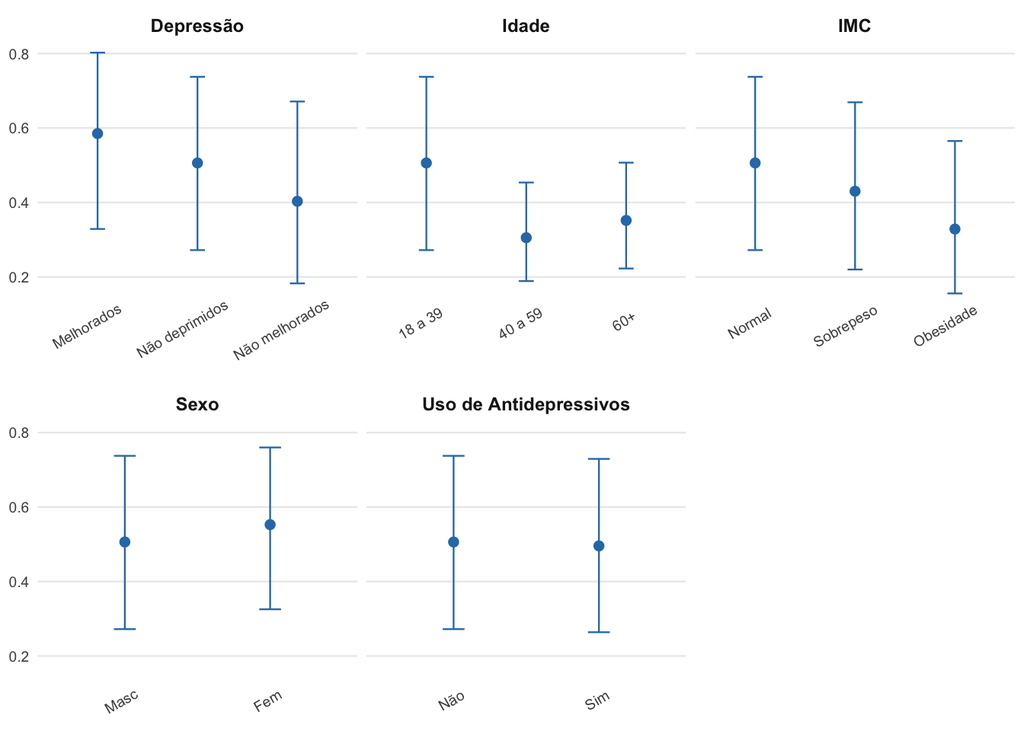

```r
#predicao por variavel
library(ggeffects)
pred_depre <- ggpredict(mod_intens, terms = "melhora_depressao3") %>%
  mutate(variavel = "Depressão",
    x = factor(
      case_when(
        x == "0" ~ "Não deprimidos",
        x == "1" ~ "Melhorados",
        x == "2" ~ "Não melhorados"
        )))

pred_idade <- ggpredict(mod_intens, terms = "IDADE_cat") %>%
  mutate(
    variavel = "Idade",
    x = factor(
      case_when(
        x == "1" ~ "18 a 39",
        x == "2" ~ "40 a 59",
        x == "3" ~ "60+"
        )
    ))


pred_sexo <- ggpredict(mod_intens, terms = "sexo_cat") %>%
  mutate(
    variavel = "Sexo",
    x = factor(
      case_when(
        x == "0" ~ "Masc",
        x == "1" ~ "Fem"
      ),
      levels = c(
        "Masc",
        "Fem"
      )
    )
  )


pred_imc <- ggpredict(mod_intens, terms = "imc_cat") %>%
  mutate(
    variavel = "IMC",
    x = factor(
      case_when(
        x == "1" ~ "Normal",
        x == "2" ~ "Sobrepeso",
        x == "3" ~ "Obesidade"
      ),
      levels = c(
        "Normal",
        "Sobrepeso",
        "Obesidade"
      )
    )
  )

pred_antidep <- ggpredict(mod_intens, terms = "Antidepressivos") %>%
  mutate(
    variavel = "Uso de Antidepressivos",
    x = factor(
      case_when(
        x == "0" ~ "Não",
        x == "1" ~ "Sim"
      ),
      levels = c(
        "Não",
        "Sim"
      )
    )
  )

pred_all_intens <- bind_rows(
  pred_antidep,
  pred_depre,
  pred_imc,
  pred_idade,
  pred_sexo
) %>%
  filter(!is.na(predicted) & !is.na(x))

library(ggplot2)
ggplot(pred_all_intens, aes(x = x, y = predicted)) +
  geom_point(size = 2, color = "#2C7BB6") +
  geom_errorbar(aes(ymin = conf.low, ymax = conf.high),
                width = 0.15,
                color = "#2C7BB6") +
  facet_wrap(~ variavel, scales = "free_x") +
  labs(
    x = NULL,
    y = NULL
  ) +
  theme_minimal(base_size = 9) +
  theme(
    strip.text = element_text(face = "bold", size = 9),
    axis.text.x = element_text(angle = 30, hjust = 0.7),
    panel.grid.minor = element_blank(),
    panel.grid.major.x = element_blank()
  )
```

#### 3.5.2 Interferência da dor

```r
#interferência da dor
banco_dor_presencial3$melhora_interf_dummy <- as.factor(banco_dor_presencial3$melhora_interf_dummy)

mod_interf <- glm(melhora_interf_dummy ~ melhora_depressao3 + sexo_cat + IDADE_cat + imc_cat + Antidepressivos,
              data = na.omit(banco_dor_presencial3),
              family = binomial)

summary(mod_interf)
```

```
Call:
glm(formula = melhora_interf_dummy ~ melhora_depressao3 + sexo_cat +
    IDADE_cat + imc_cat + Antidepressivos, family = binomial,
    data = na.omit(banco_dor_presencial3))

Coefficients:
                    Estimate Std. Error z value Pr(>|z|)
(Intercept)         -1.80625    0.57250  -3.155  0.00161 **
melhora_depressao31  0.64893    0.25343   2.561  0.01045 *
melhora_depressao32 -0.21962    0.25414  -0.864  0.38749
sexo_cat1            0.64172    0.25939   2.474  0.01336 *
IDADE_cat2           0.61568    0.49694   1.239  0.21537
IDADE_cat3           0.49938    0.50636   0.986  0.32403
imc_cat2            -0.07765    0.26734  -0.290  0.77145
imc_cat3            -0.28763    0.25760  -1.117  0.26417
Antidepressivos1     0.10810    0.20385   0.530  0.59589
---
Signif. codes:  0 '***' 0.001 '**' 0.01 '*' 0.05 '.' 0.1 ' ' 1

(Dispersion parameter for binomial family taken to be 1)

    Null deviance: 621.51  on 498  degrees of freedom
Residual deviance: 602.19  on 490  degrees of freedom
AIC: 620.19

Number of Fisher Scoring iterations: 4
```

```r
exp(coef(mod_interf))
```

```
        (Intercept) melhora_depressao31 melhora_depressao32           sexo_cat1
          0.1642689           1.9134910           0.8028223           1.8997363
         IDADE_cat2          IDADE_cat3            imc_cat2            imc_cat3
          1.8509181           1.6477011           0.9252839           0.7500393
   Antidepressivos1
          1.1141627
```

```r
exp(confint(mod_interf))
```

```
                         2.5 %    97.5 %
(Intercept)         0.04986044 0.4812612
melhora_depressao31 1.16247330 3.1457592
melhora_depressao32 0.48353291 1.3125227
sexo_cat1           1.15788237 3.2126590
IDADE_cat2          0.73654710 5.3325905
IDADE_cat3          0.64204893 4.8198815
imc_cat2            0.54862833 1.5677447
imc_cat3            0.45355027 1.2474830
Antidepressivos1    0.74617023 1.6606673
```

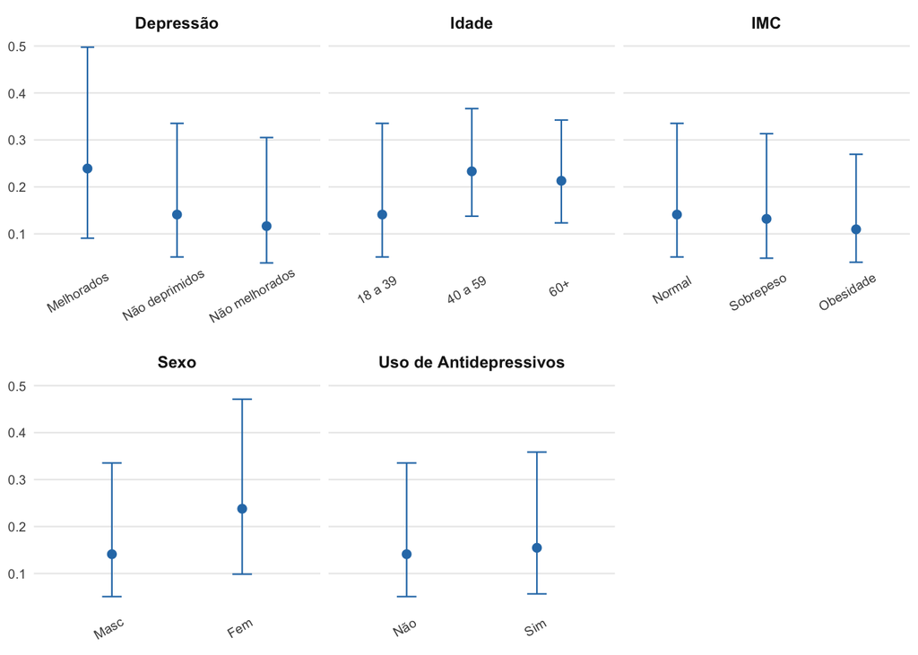

```r
#predicao por variavel
pred_depre <- ggpredict(mod_interf, terms = "melhora_depressao3") %>%
  mutate(variavel = "Depressão",
    x = factor(
      case_when(
        x == "0" ~ "Não deprimidos",
        x == "1" ~ "Melhorados",
        x == "2" ~ "Não melhorados"
        )))

pred_idade <- ggpredict(mod_interf, terms = "IDADE_cat") %>%
  mutate(
    variavel = "Idade",
    x = factor(
      case_when(
        x == "1" ~ "18 a 39",
        x == "2" ~ "40 a 59",
        x == "3" ~ "60+"
        )
    ))


pred_sexo <- ggpredict(mod_interf, terms = "sexo_cat") %>%
  mutate(
    variavel = "Sexo",
    x = factor(
      case_when(
        x == "0" ~ "Masc",
        x == "1" ~ "Fem"
      ),
      levels = c(
        "Masc",
        "Fem"
      )
    )
  )


pred_imc <- ggpredict(mod_interf, terms = "imc_cat") %>%
  mutate(
    variavel = "IMC",
    x = factor(
      case_when(
        x == "1" ~ "Normal",
        x == "2" ~ "Sobrepeso",
        x == "3" ~ "Obesidade"
      ),
      levels = c(
        "Normal",
        "Sobrepeso",
        "Obesidade"
      )
    )
  )

pred_antidep <- ggpredict(mod_interf, terms = "Antidepressivos") %>%
  mutate(
    variavel = "Uso de Antidepressivos",
    x = factor(
      case_when(
        x == "0" ~ "Não",
        x == "1" ~ "Sim"
      ),
      levels = c(
        "Não",
        "Sim"
      )
    )
  )

pred_all_interf <- bind_rows(
  pred_antidep,
  pred_depre,
  pred_imc,
  pred_idade,
  pred_sexo
) %>%
  filter(!is.na(predicted) & !is.na(x))

library(ggplot2)
ggplot(pred_all_interf, aes(x = x, y = predicted)) +
  geom_point(size = 2, color = "#2C7BB6") +
  geom_errorbar(aes(ymin = conf.low, ymax = conf.high),
                width = 0.15,
                color = "#2C7BB6") +
  facet_wrap(~ variavel, scales = "free_x") +
  labs(
    x = NULL,
    y = NULL
  ) +
  theme_minimal(base_size = 9) +
  theme(
    strip.text = element_text(face = "bold", size = 9),
    axis.text.x = element_text(angle = 30, hjust = 0.7),
    panel.grid.minor = element_blank(),
    panel.grid.major.x = element_blank()
  )
```